# Milestone Report

Sheetal

4 March 2019

## Introduction

This is the milstone report for the coursera data science capstone. the capstone project is to create a predictive text model using a large text corpus of documents as training data. Natural language processing techniques will be used to perform the analysis and build the predictive model.

```r
library(plyr)
library(dplyr)
library(knitr)
library(tm)
```

# Downloading the data

The data sets consist of text from 3 different sources: 1) News, 2) Blogs and 3) Twitter feeds.

```r
twitter<-file("en_US.twitter.txt","r")
twitter_lines<-readLines(twitter)
close(twitter)


blogs<-file("en_US.blogs.txt","r")
blogs_lines<-readLines(blogs)
close(blogs)

news<-file("en_US.news.txt","r")
news_lines<-readLines(news)
close(news)
```

# basic summary stats

To start to understand the data imported. We will examine line counts, word counts and mean words per line.

```r
library(stringi)
# Get words in files
lineBlogs.words <- stri_count_words(blogs_lines)
lineNews.words <- stri_count_words(news_lines)
lineTwitter.words <- stri_count_words(twitter_lines)
# Summary of the data sets
data.frame(source = c("blogs", "news", "twitter"),
           num.lines = c(length(blogs_lines), length(news_lines), length(twitter_lines)),
           num.words = c(sum(lineBlogs.words), sum(lineNews.words), sum(lineTwitter.words)),
           mean.num.words = c(mean(lineBlogs.words), mean(lineNews.words), mean(lineTwitter.words)))
```

```
##    source num.lines num.words mean.num.words
## 1   blogs    899288  38154238       42.42716
## 2    news     77259   2693898       34.86840
## 3 twitter   2360148  30218125       12.80349
```

# sampling and cleaning the data

Before performing exploratory analysis, we must clean the data first. This involves removing URLs, special characters, punctuations, numbers, excess whitespace, stopwords, and changing the text to lower case. Since the data sets are quite large, we will randomly choose 2% of the data to demonstrate the data cleaning and exploratory analysisThe english language has around 5k commonly used wordS. This means we wont need to use all the data, and should be able to take a sample.

```r
library(tm)
# Sample the data
set.seed(5000)
data.sample <- c(sample(blogs_lines, length(blogs_lines) * 0.02),
                 sample(news_lines, length(news_lines) * 0.02),
                 sample(twitter_lines, length(twitter_lines) * 0.02))
# Create corpus and clean the data
corpus <- VCorpus(VectorSource(data.sample))
toSpace <- content_transformer(function(x, pattern) gsub(pattern, " ", x))
corpus <- tm_map(corpus, toSpace, "(f|ht)tp(s?)://(.*)[.][a-z]+")
corpus <- tm_map(corpus, toSpace, "@[^\\s]+")
corpus <- tm_map(corpus, tolower)
corpus <- tm_map(corpus, removeWords, stopwords("en"))
corpus <- tm_map(corpus, removePunctuation)
corpus <- tm_map(corpus, removeNumbers)
corpus <- tm_map(corpus, stripWhitespace)
corpus <- tm_map(corpus, PlainTextDocument)
dataframe<-data.frame(text=unlist(sapply(corpus, `[`, "content")), stringsAsFactors=FALSE)
```

# view the data

The dataset is now ready to be viewed.We have 66732 sentences

```r
head(dataframe,2)
```

```
##                                                                                                                                                                                                                                                                                                          …
## 1 julia powered american taxpayer subsidies thinfilm photovoltaic solar cells also funded american taxpayers miraculous combination federal tax dollars hope enlightened postpartisan leadership creatorâpresident barack obamaâjulia acquired artificial intelligence almost indistinguishable mankind w…
## 2                                                                                                                                                                         anyways made vlog couple weeks ago just video whats bag done post just felt mood something different well find filming easier t…
```

```r
#Num lines
length(dataframe)
```

```
## [1] 1
```

```r
#Num terms
sum(sapply(dataframe, length))
```

```
## [1] 66732
```

```r
frequencyTable <- function(termList){
  term <- data.frame(unlist(termList))
  grouped <- as.data.frame(table(term))
  freq <- grouped[order(-grouped$Freq),]
  rownames(freq) <- 1:nrow(freq)

  total <- sum(freq$Freq)
  freq$CumFreq <- cumsum(freq$Freq)
  freq$Coverage <- freq$CumFreq/total

  return(freq)
}
sampleENTermFrequency <- frequencyTable(dataframe)
head(sampleENTermFrequency, 15)
```

```
##                term Freq CumFreq    Coverage
## 1                    207     207 0.003101960
## 2            thank    50     257 0.003851226
## 3         thanks rt   38     295 0.004420668
## 4             love    25     320 0.004795301
## 5                     21     341 0.005109992
## 6     thanks follow   18     359 0.005379728
## 7             love    17     376 0.005634478
## 8           welcome   16     392 0.005874243
## 9              know   14     406 0.006084038
## 10          follow    13     419 0.006278847
## 11 thanks following   13     432 0.006473656
## 12   happy birthday   12     444 0.006653480
## 13            like    11     455 0.006818318
## 14            miss    11     466 0.006983157
## 15             true   11     477 0.007147995
```

```r
library(ggplot2)
sampleENTermFrequency <- frequencyTable(dataframe)
head(sampleENTermFrequency, 15)
```

```
##                term Freq CumFreq    Coverage
## 1                    207     207 0.003101960
## 2            thank    50     257 0.003851226
## 3         thanks rt   38     295 0.004420668
## 4             love    25     320 0.004795301
## 5                     21     341 0.005109992
## 6     thanks follow   18     359 0.005379728
## 7             love    17     376 0.005634478
## 8           welcome   16     392 0.005874243
## 9              know   14     406 0.006084038
## 10          follow    13     419 0.006278847
## 11 thanks following   13     432 0.006473656
## 12   happy birthday   12     444 0.006653480
## 13            like    11     455 0.006818318
## 14            miss    11     466 0.006983157
## 15             true   11     477 0.007147995
```

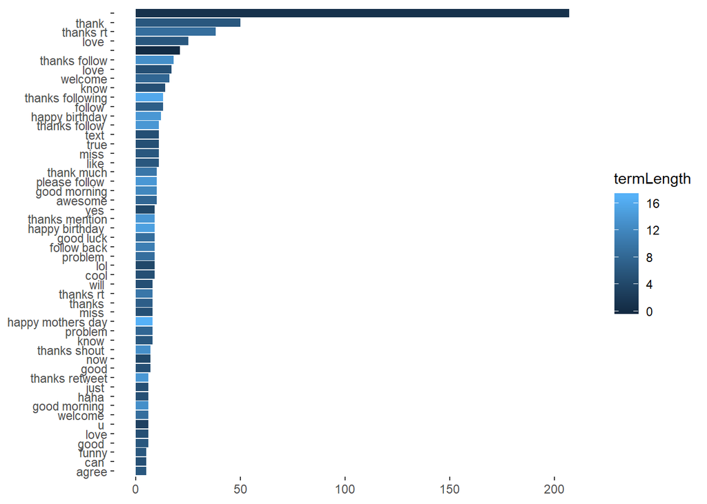

```r
tmp <- sampleENTermFrequency[1:50,]
tmp$termLength <-  nchar(as.character(tmp$term))
ggplot(tmp, aes(x=reorder(term,Freq), y=Freq, fill=termLength)) +
    geom_bar(stat="identity") +
    coord_flip() +
    theme(panel.border = element_blank(),
          panel.grid.major = element_blank(),
          panel.grid.minor = element_blank(),
          panel.background = element_blank(),
          axis.title.y=element_blank(),
          axis.title.x=element_blank())
```